# Risk Factor Analysis

## Outcome Variable

**Outcome Variable:** pers_wast

## Predictor Variables

**Intervention Variable:** exclfeed6

**Adjustment Set:**

- arm
- sex
- W_mage
- meducyrs
- feducyrs
- hhwealth_quart
- hfoodsec
- W_mhtcm
- vagbrth
- W_birthwt
- W_birthlen
- W_nrooms
- month
- brthmon
- W_parity
- impfloor
- impsan
- safeh20
- delta_W_mage
- delta_meducyrs
- delta_feducyrs
- delta_hhwealth_quart
- delta_hfoodsec
- delta_W_mhtcm
- delta_vagbrth
- delta_W_birthwt
- delta_W_birthlen
- delta_W_nrooms
- delta_month
- delta_brthmon
- delta_W_parity
- delta_impfloor
- delta_impsan
- delta_safeh20

## Stratifying Variables

The analysis was stratified on these variable(s):

- agecat
- studyid
- country

## Data Summary

| agecat | studyid | country | exclfeed6 | pers_wast | n_cell | n |
| --- | --- | --- | --- | --- | --- | --- |
| 0-24 months | ki0047075b-MAL-ED | BANGLADESH | 0 | 0 | 171 | 238 |
| 0-24 months | ki0047075b-MAL-ED | BANGLADESH | 0 | 1 | 9 | 238 |
| 0-24 months | ki0047075b-MAL-ED | BANGLADESH | 1 | 0 | 54 | 238 |
| 0-24 months | ki0047075b-MAL-ED | BANGLADESH | 1 | 1 | 4 | 238 |
| 0-24 months | ki0047075b-MAL-ED | BRAZIL | 0 | 0 | 193 | 212 |
| 0-24 months | ki0047075b-MAL-ED | BRAZIL | 0 | 1 | 2 | 212 |
| 0-24 months | ki0047075b-MAL-ED | BRAZIL | 1 | 0 | 17 | 212 |
| 0-24 months | ki0047075b-MAL-ED | BRAZIL | 1 | 1 | 0 | 212 |
| 0-24 months | ki0047075b-MAL-ED | INDIA | 0 | 0 | 209 | 234 |
| 0-24 months | ki0047075b-MAL-ED | INDIA | 0 | 1 | 19 | 234 |
| 0-24 months | ki0047075b-MAL-ED | INDIA | 1 | 0 | 6 | 234 |
| 0-24 months | ki0047075b-MAL-ED | INDIA | 1 | 1 | 0 | 234 |
| 0-24 months | ki0047075b-MAL-ED | NEPAL | 0 | 0 | 217 | 235 |
| 0-24 months | ki0047075b-MAL-ED | NEPAL | 0 | 1 | 3 | 235 |
| 0-24 months | ki0047075b-MAL-ED | NEPAL | 1 | 0 | 15 | 235 |
| 0-24 months | ki0047075b-MAL-ED | NEPAL | 1 | 1 | 0 | 235 |
| 0-24 months | ki0047075b-MAL-ED | PERU | 0 | 0 | 258 | 270 |
| 0-24 months | ki0047075b-MAL-ED | PERU | 0 | 1 | 1 | 270 |
| 0-24 months | ki0047075b-MAL-ED | PERU | 1 | 0 | 11 | 270 |
| 0-24 months | ki0047075b-MAL-ED | PERU | 1 | 1 | 0 | 270 |
| 0-24 months | ki0047075b-MAL-ED | SOUTH AFRICA | 0 | 0 | 246 | 248 |
| 0-24 months | ki0047075b-MAL-ED | SOUTH AFRICA | 0 | 1 | 2 | 248 |
| 0-24 months | ki0047075b-MAL-ED | SOUTH AFRICA | 1 | 0 | 0 | 248 |
| 0-24 months | ki0047075b-MAL-ED | SOUTH AFRICA | 1 | 1 | 0 | 248 |
| 0-24 months | ki0047075b-MAL-ED | TANZANIA, UNITED REPUBLIC OF | 0 | 0 | 247 | 248 |
| 0-24 months | ki0047075b-MAL-ED | TANZANIA, UNITED REPUBLIC OF | 0 | 1 | 0 | 248 |
| 0-24 months | ki0047075b-MAL-ED | TANZANIA, UNITED REPUBLIC OF | 1 | 0 | 1 | 248 |
| 0-24 months | ki0047075b-MAL-ED | TANZANIA, UNITED REPUBLIC OF | 1 | 1 | 0 | 248 |
| 0-24 months | ki1000108-CMC-V-BCS-2002 | INDIA | 0 | 0 | 0 | 19 |
| 0-24 months | ki1000108-CMC-V-BCS-2002 | INDIA | 0 | 1 | 0 | 19 |

[output cut: 162 more lines]

The following strata were considered:

- agecat: 0-24 months, studyid: ki0047075b-MAL-ED, country: BANGLADESH
- agecat: 0-24 months, studyid: ki0047075b-MAL-ED, country: BRAZIL
- agecat: 0-24 months, studyid: ki0047075b-MAL-ED, country: INDIA
- agecat: 0-24 months, studyid: ki0047075b-MAL-ED, country: NEPAL
- agecat: 0-24 months, studyid: ki0047075b-MAL-ED, country: PERU
- agecat: 0-24 months, studyid: ki0047075b-MAL-ED, country: SOUTH AFRICA
- agecat: 0-24 months, studyid: ki0047075b-MAL-ED, country: TANZANIA, UNITED REPUBLIC OF
- agecat: 0-24 months, studyid: ki1000108-CMC-V-BCS-2002, country: INDIA
- agecat: 0-24 months, studyid: ki1000108-IRC, country: INDIA
- agecat: 0-24 months, studyid: ki1000109-EE, country: PAKISTAN
- agecat: 0-24 months, studyid: ki1000304b-SAS-CompFeed, country: INDIA
- agecat: 0-24 months, studyid: ki1000304b-SAS-FoodSuppl, country: INDIA
- agecat: 0-24 months, studyid: ki1017093b-PROVIDE, country: BANGLADESH
- agecat: 0-24 months, studyid: ki1101329-Keneba, country: GAMBIA
- agecat: 0-24 months, studyid: ki1113344-GMS-Nepal, country: NEPAL
- agecat: 0-24 months, studyid: ki1148112-LCNI-5, country: MALAWI
- agecat: 0-24 months, studyid: kiGH5241-JiVitA-3, country: BANGLADESH
- agecat: 0-24 months, studyid: kiGH5241-JiVitA-4, country: BANGLADESH
- agecat: 0-6 months, studyid: ki0047075b-MAL-ED, country: BANGLADESH
- agecat: 0-6 months, studyid: ki0047075b-MAL-ED, country: BRAZIL
- agecat: 0-6 months, studyid: ki0047075b-MAL-ED, country: INDIA
- agecat: 0-6 months, studyid: ki0047075b-MAL-ED, country: NEPAL
- agecat: 0-6 months, studyid: ki0047075b-MAL-ED, country: PERU
- agecat: 0-6 months, studyid: ki0047075b-MAL-ED, country: SOUTH AFRICA
- agecat: 0-6 months, studyid: ki0047075b-MAL-ED, country: TANZANIA, UNITED REPUBLIC OF
- agecat: 0-6 months, studyid: ki1000108-CMC-V-BCS-2002, country: INDIA
- agecat: 0-6 months, studyid: ki1000108-IRC, country: INDIA
- agecat: 0-6 months, studyid: ki1000109-EE, country: PAKISTAN
- agecat: 0-6 months, studyid: ki1017093b-PROVIDE, country: BANGLADESH
- agecat: 0-6 months, studyid: ki1101329-Keneba, country: GAMBIA
- agecat: 0-6 months, studyid: ki1113344-GMS-Nepal, country: NEPAL
- agecat: 6-24 months, studyid: ki0047075b-MAL-ED, country: BANGLADESH
- agecat: 6-24 months, studyid: ki0047075b-MAL-ED, country: BRAZIL
- agecat: 6-24 months, studyid: ki0047075b-MAL-ED, country: INDIA
- agecat: 6-24 months, studyid: ki0047075b-MAL-ED, country: NEPAL
- agecat: 6-24 months, studyid: ki0047075b-MAL-ED, country: PERU
- agecat: 6-24 months, studyid: ki0047075b-MAL-ED, country: SOUTH AFRICA
- agecat: 6-24 months, studyid: ki0047075b-MAL-ED, country: TANZANIA, UNITED REPUBLIC OF
- agecat: 6-24 months, studyid: ki1000108-CMC-V-BCS-2002, country: INDIA
- agecat: 6-24 months, studyid: ki1000108-IRC, country: INDIA
- agecat: 6-24 months, studyid: ki1000109-EE, country: PAKISTAN
- agecat: 6-24 months, studyid: ki1000304b-SAS-CompFeed, country: INDIA
- agecat: 6-24 months, studyid: ki1000304b-SAS-FoodSuppl, country: INDIA
- agecat: 6-24 months, studyid: ki1017093b-PROVIDE, country: BANGLADESH
- agecat: 6-24 months, studyid: ki1101329-Keneba, country: GAMBIA
- agecat: 6-24 months, studyid: ki1113344-GMS-Nepal, country: NEPAL
- agecat: 6-24 months, studyid: ki1148112-LCNI-5, country: MALAWI
- agecat: 6-24 months, studyid: kiGH5241-JiVitA-4, country: BANGLADESH

### Dropped Strata

Some strata were dropped due to rare outcomes:

- agecat: 0-24 months, studyid: ki0047075b-MAL-ED, country: BANGLADESH
- agecat: 0-24 months, studyid: ki0047075b-MAL-ED, country: BRAZIL
- agecat: 0-24 months, studyid: ki0047075b-MAL-ED, country: INDIA
- agecat: 0-24 months, studyid: ki0047075b-MAL-ED, country: NEPAL
- agecat: 0-24 months, studyid: ki0047075b-MAL-ED, country: PERU
- agecat: 0-24 months, studyid: ki0047075b-MAL-ED, country: SOUTH AFRICA
- agecat: 0-24 months, studyid: ki0047075b-MAL-ED, country: TANZANIA, UNITED REPUBLIC OF
- agecat: 0-24 months, studyid: ki1000108-CMC-V-BCS-2002, country: INDIA
- agecat: 0-24 months, studyid: ki1000108-IRC, country: INDIA
- agecat: 0-24 months, studyid: ki1000304b-SAS-CompFeed, country: INDIA
- agecat: 0-24 months, studyid: ki1000304b-SAS-FoodSuppl, country: INDIA
- agecat: 0-24 months, studyid: ki1017093b-PROVIDE, country: BANGLADESH
- agecat: 0-24 months, studyid: ki1148112-LCNI-5, country: MALAWI
- agecat: 0-6 months, studyid: ki0047075b-MAL-ED, country: BANGLADESH
- agecat: 0-6 months, studyid: ki0047075b-MAL-ED, country: BRAZIL
- agecat: 0-6 months, studyid: ki0047075b-MAL-ED, country: INDIA
- agecat: 0-6 months, studyid: ki0047075b-MAL-ED, country: NEPAL
- agecat: 0-6 months, studyid: ki0047075b-MAL-ED, country: PERU
- agecat: 0-6 months, studyid: ki0047075b-MAL-ED, country: SOUTH AFRICA
- agecat: 0-6 months, studyid: ki0047075b-MAL-ED, country: TANZANIA, UNITED REPUBLIC OF
- agecat: 0-6 months, studyid: ki1000108-CMC-V-BCS-2002, country: INDIA
- agecat: 0-6 months, studyid: ki1000108-IRC, country: INDIA
- agecat: 0-6 months, studyid: ki1017093b-PROVIDE, country: BANGLADESH
- agecat: 6-24 months, studyid: ki0047075b-MAL-ED, country: BRAZIL
- agecat: 6-24 months, studyid: ki0047075b-MAL-ED, country: INDIA
- agecat: 6-24 months, studyid: ki0047075b-MAL-ED, country: NEPAL
- agecat: 6-24 months, studyid: ki0047075b-MAL-ED, country: PERU
- agecat: 6-24 months, studyid: ki0047075b-MAL-ED, country: SOUTH AFRICA
- agecat: 6-24 months, studyid: ki0047075b-MAL-ED, country: TANZANIA, UNITED REPUBLIC OF
- agecat: 6-24 months, studyid: ki1000108-CMC-V-BCS-2002, country: INDIA
- agecat: 6-24 months, studyid: ki1000108-IRC, country: INDIA
- agecat: 6-24 months, studyid: ki1000304b-SAS-CompFeed, country: INDIA
- agecat: 6-24 months, studyid: ki1000304b-SAS-FoodSuppl, country: INDIA
- agecat: 6-24 months, studyid: ki1148112-LCNI-5, country: MALAWI

## Methods Detail

We’re interested in the causal parameters $E[Y_a]$ for all values of $a \in \mathcal{A}$. These parameters represent the mean outcome if, possibly contrary to fact, we intervened to set all units to have $A=a$. Under the randomization and positivity assumptions, these are identified by the statistical parameters $\psi_a=E_W[E_{Y|A,W}(Y|A=a,W)]$. In addition, we’re interested in the mean of $Y$, $E[Y]$ under no intervention (the observed mean). We will estimate these parameters by using SuperLearner to fit the relevant likelihood factors – $E_{Y|A,W}(Y|A=a,W)$ and $p(A=a|W)$, and then updating our likelihood fit using a joint TMLE.

For unadjusted analyses ($W=\{\}$), initial likelihoods were estimated using Lrnr_glm to estimate the simple $E(Y|A)$ and Lrnr_mean to estimate $p(A)$. For adjusted analyses, a small library containing Lrnr_glmnet, Lrnr_xgboost, and Lrnr_mean was used.

Having estimated these parameters, we will then use the delta method to estimate relative risks and attributable risks relative to a prespecified baseline level of $A$.

# Results Detail

## Results Plots

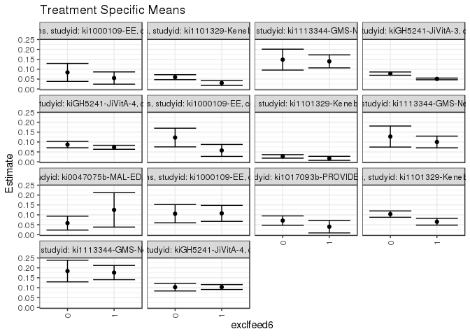

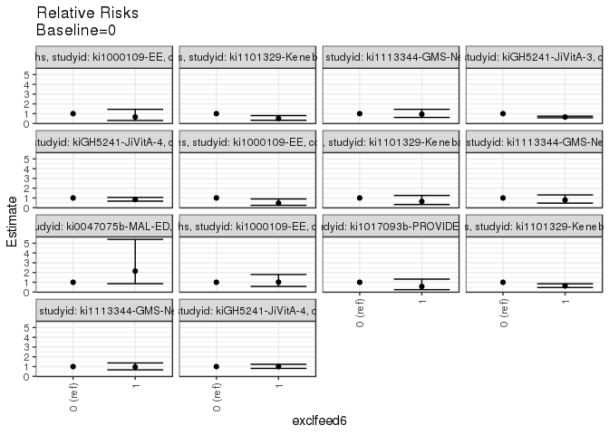

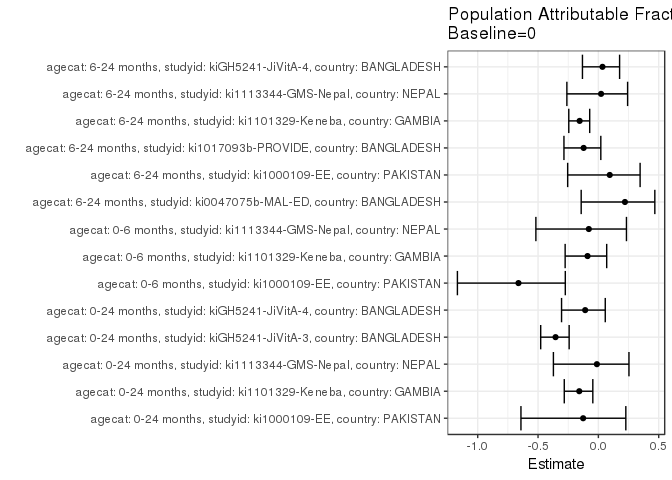

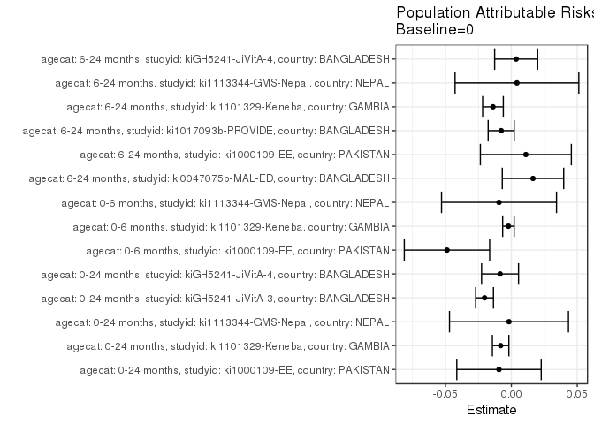

## Results Table

### Parameter: TSM

| agecat | studyid | country | intervention_level | baseline_level | estimate | ci_lower | ci_upper |
| --- | --- | --- | --- | --- | --- | --- | --- |
| 0-24 months | ki1000109-EE | PAKISTAN | 0 | NA | 0.0836392 | 0.0381614 | 0.1291170 |
| 0-24 months | ki1000109-EE | PAKISTAN | 1 | NA | 0.0552328 | 0.0242775 | 0.0861882 |
| 0-24 months | ki1101329-Keneba | GAMBIA | 0 | NA | 0.0595550 | 0.0470614 | 0.0720487 |
| 0-24 months | ki1101329-Keneba | GAMBIA | 1 | NA | 0.0301071 | 0.0176991 | 0.0425151 |
| 0-24 months | ki1113344-GMS-Nepal | NEPAL | 0 | NA | 0.1482340 | 0.0954472 | 0.2010209 |
| 0-24 months | ki1113344-GMS-Nepal | NEPAL | 1 | NA | 0.1394335 | 0.1065913 | 0.1722757 |
| 0-24 months | kiGH5241-JiVitA-3 | BANGLADESH | 0 | NA | 0.0776260 | 0.0693603 | 0.0858917 |
| 0-24 months | kiGH5241-JiVitA-3 | BANGLADESH | 1 | NA | 0.0508629 | 0.0466394 | 0.0550864 |
| 0-24 months | kiGH5241-JiVitA-4 | BANGLADESH | 0 | NA | 0.0869372 | 0.0707767 | 0.1030977 |
| 0-24 months | kiGH5241-JiVitA-4 | BANGLADESH | 1 | NA | 0.0733095 | 0.0632201 | 0.0833988 |
| 0-6 months | ki1000109-EE | PAKISTAN | 0 | NA | 0.1226171 | 0.0754715 | 0.1697626 |
| 0-6 months | ki1000109-EE | PAKISTAN | 1 | NA | 0.0574392 | 0.0273675 | 0.0875108 |
| 0-6 months | ki1101329-Keneba | GAMBIA | 0 | NA | 0.0272710 | 0.0184278 | 0.0361142 |
| 0-6 months | ki1101329-Keneba | GAMBIA | 1 | NA | 0.0175161 | 0.0072211 | 0.0278111 |
| 0-6 months | ki1113344-GMS-Nepal | NEPAL | 0 | NA | 0.1275546 | 0.0743775 | 0.1807318 |
| 0-6 months | ki1113344-GMS-Nepal | NEPAL | 1 | NA | 0.1001851 | 0.0705756 | 0.1297946 |
| 6-24 months | ki0047075b-MAL-ED | BANGLADESH | 0 | NA | 0.0581395 | 0.0230912 | 0.0931879 |
| 6-24 months | ki0047075b-MAL-ED | BANGLADESH | 1 | NA | 0.1250000 | 0.0381904 | 0.2118096 |
| 6-24 months | ki1000109-EE | PAKISTAN | 0 | NA | 0.1058505 | 0.0596474 | 0.1520537 |
| 6-24 months | ki1000109-EE | PAKISTAN | 1 | NA | 0.1074750 | 0.0670579 | 0.1478920 |
| 6-24 months | ki1017093b-PROVIDE | BANGLADESH | 0 | NA | 0.0709534 | 0.0472382 | 0.0946686 |
| 6-24 months | ki1017093b-PROVIDE | BANGLADESH | 1 | NA | 0.0400000 | 0.0086145 | 0.0713856 |
| 6-24 months | ki1101329-Keneba | GAMBIA | 0 | NA | 0.1037290 | 0.0877209 | 0.1197370 |
| 6-24 months | ki1101329-Keneba | GAMBIA | 1 | NA | 0.0650886 | 0.0480373 | 0.0821399 |
| 6-24 months | ki1113344-GMS-Nepal | NEPAL | 0 | NA | 0.1840663 | 0.1293010 | 0.2388316 |
| 6-24 months | ki1113344-GMS-Nepal | NEPAL | 1 | NA | 0.1761930 | 0.1402608 | 0.2121252 |
| 6-24 months | kiGH5241-JiVitA-4 | BANGLADESH | 0 | NA | 0.1027123 | 0.0833385 | 0.1220862 |
| 6-24 months | kiGH5241-JiVitA-4 | BANGLADESH | 1 | NA | 0.1030694 | 0.0907119 | 0.1154269 |

### Parameter: E(Y)

| agecat | studyid | country | intervention_level | baseline_level | estimate | ci_lower | ci_upper |
| --- | --- | --- | --- | --- | --- | --- | --- |
| 0-24 months | ki1000109-EE | PAKISTAN | NA | NA | 0.0742706 | 0.0477670 | 0.1007741 |
| 0-24 months | ki1101329-Keneba | GAMBIA | NA | NA | 0.0514151 | 0.0420121 | 0.0608181 |
| 0-24 months | ki1113344-GMS-Nepal | NEPAL | NA | NA | 0.1464286 | 0.1171213 | 0.1757358 |
| 0-24 months | kiGH5241-JiVitA-3 | BANGLADESH | NA | NA | 0.0572887 | 0.0532017 | 0.0613756 |
| 0-24 months | kiGH5241-JiVitA-4 | BANGLADESH | NA | NA | 0.0783679 | 0.0692461 | 0.0874896 |
| 0-6 months | ki1000109-EE | PAKISTAN | NA | NA | 0.0737705 | 0.0469540 | 0.1005870 |
| 0-6 months | ki1101329-Keneba | GAMBIA | NA | NA | 0.0250261 | 0.0180336 | 0.0320185 |
| 0-6 months | ki1113344-GMS-Nepal | NEPAL | NA | NA | 0.1181989 | 0.0907652 | 0.1456326 |
| 6-24 months | ki0047075b-MAL-ED | BANGLADESH | NA | NA | 0.0745614 | 0.0403897 | 0.1087331 |
| 6-24 months | ki1000109-EE | PAKISTAN | NA | NA | 0.1168478 | 0.0839821 | 0.1497135 |
| 6-24 months | ki1017093b-PROVIDE | BANGLADESH | NA | NA | 0.0632280 | 0.0437545 | 0.0827015 |
| 6-24 months | ki1101329-Keneba | GAMBIA | NA | NA | 0.0897833 | 0.0770525 | 0.1025140 |
| 6-24 months | ki1113344-GMS-Nepal | NEPAL | NA | NA | 0.1882998 | 0.1555073 | 0.2210923 |
| 6-24 months | kiGH5241-JiVitA-4 | BANGLADESH | NA | NA | 0.1063445 | 0.0949209 | 0.1177682 |

### Parameter: RR

| agecat | studyid | country | intervention_level | baseline_level | estimate | ci_lower | ci_upper |
| --- | --- | --- | --- | --- | --- | --- | --- |
| 0-24 months | ki1000109-EE | PAKISTAN | 0 | 0 | 1.0000000 | 1.0000000 | 1.0000000 |
| 0-24 months | ki1000109-EE | PAKISTAN | 1 | 0 | 0.6603698 | 0.3025306 | 1.4414683 |
| 0-24 months | ki1101329-Keneba | GAMBIA | 0 | 0 | 1.0000000 | 1.0000000 | 1.0000000 |
| 0-24 months | ki1101329-Keneba | GAMBIA | 1 | 0 | 0.5055348 | 0.3185648 | 0.8022400 |
| 0-24 months | ki1113344-GMS-Nepal | NEPAL | 0 | 0 | 1.0000000 | 1.0000000 | 1.0000000 |
| 0-24 months | ki1113344-GMS-Nepal | NEPAL | 1 | 0 | 0.9406307 | 0.6136946 | 1.4417369 |
| 0-24 months | kiGH5241-JiVitA-3 | BANGLADESH | 0 | 0 | 1.0000000 | 1.0000000 | 1.0000000 |
| 0-24 months | kiGH5241-JiVitA-3 | BANGLADESH | 1 | 0 | 0.6552298 | 0.5773701 | 0.7435890 |
| 0-24 months | kiGH5241-JiVitA-4 | BANGLADESH | 0 | 0 | 1.0000000 | 1.0000000 | 1.0000000 |
| 0-24 months | kiGH5241-JiVitA-4 | BANGLADESH | 1 | 0 | 0.8432466 | 0.6748183 | 1.0537130 |
| 0-6 months | ki1000109-EE | PAKISTAN | 0 | 0 | 1.0000000 | 1.0000000 | 1.0000000 |
| 0-6 months | ki1000109-EE | PAKISTAN | 1 | 0 | 0.4684434 | 0.2444125 | 0.8978230 |
| 0-6 months | ki1101329-Keneba | GAMBIA | 0 | 0 | 1.0000000 | 1.0000000 | 1.0000000 |
| 0-6 months | ki1101329-Keneba | GAMBIA | 1 | 0 | 0.6422991 | 0.3283253 | 1.2565225 |
| 0-6 months | ki1113344-GMS-Nepal | NEPAL | 0 | 0 | 1.0000000 | 1.0000000 | 1.0000000 |
| 0-6 months | ki1113344-GMS-Nepal | NEPAL | 1 | 0 | 0.7854290 | 0.4713742 | 1.3087240 |
| 6-24 months | ki0047075b-MAL-ED | BANGLADESH | 0 | 0 | 1.0000000 | 1.0000000 | 1.0000000 |
| 6-24 months | ki0047075b-MAL-ED | BANGLADESH | 1 | 0 | 2.1500000 | 0.8571404 | 5.3929318 |
| 6-24 months | ki1000109-EE | PAKISTAN | 0 | 0 | 1.0000000 | 1.0000000 | 1.0000000 |
| 6-24 months | ki1000109-EE | PAKISTAN | 1 | 0 | 1.0153466 | 0.5741821 | 1.7954735 |
| 6-24 months | ki1017093b-PROVIDE | BANGLADESH | 0 | 0 | 1.0000000 | 1.0000000 | 1.0000000 |
| 6-24 months | ki1017093b-PROVIDE | BANGLADESH | 1 | 0 | 0.5637501 | 0.2402669 | 1.3227548 |
| 6-24 months | ki1101329-Keneba | GAMBIA | 0 | 0 | 1.0000000 | 1.0000000 | 1.0000000 |
| 6-24 months | ki1101329-Keneba | GAMBIA | 1 | 0 | 0.6274870 | 0.4658058 | 0.8452877 |
| 6-24 months | ki1113344-GMS-Nepal | NEPAL | 0 | 0 | 1.0000000 | 1.0000000 | 1.0000000 |
| 6-24 months | ki1113344-GMS-Nepal | NEPAL | 1 | 0 | 0.9572259 | 0.6684762 | 1.3707015 |
| 6-24 months | kiGH5241-JiVitA-4 | BANGLADESH | 0 | 0 | 1.0000000 | 1.0000000 | 1.0000000 |
| 6-24 months | kiGH5241-JiVitA-4 | BANGLADESH | 1 | 0 | 1.0034765 | 0.8164931 | 1.2332806 |

### Parameter: PAR

| agecat | studyid | country | intervention_level | baseline_level | estimate | ci_lower | ci_upper |
| --- | --- | --- | --- | --- | --- | --- | --- |
| 0-24 months | ki1000109-EE | PAKISTAN | 0 | NA | -0.0093687 | -0.0413929 | 0.0226555 |
| 0-24 months | ki1101329-Keneba | GAMBIA | 0 | NA | -0.0081400 | -0.0143968 | -0.0018831 |
| 0-24 months | ki1113344-GMS-Nepal | NEPAL | 0 | NA | -0.0018054 | -0.0469324 | 0.0433216 |
| 0-24 months | kiGH5241-JiVitA-3 | BANGLADESH | 0 | NA | -0.0203373 | -0.0270882 | -0.0135865 |
| 0-24 months | kiGH5241-JiVitA-4 | BANGLADESH | 0 | NA | -0.0085693 | -0.0225929 | 0.0054543 |
| 0-6 months | ki1000109-EE | PAKISTAN | 0 | NA | -0.0488466 | -0.0812272 | -0.0164659 |
| 0-6 months | ki1101329-Keneba | GAMBIA | 0 | NA | -0.0022449 | -0.0065980 | 0.0021082 |
| 0-6 months | ki1113344-GMS-Nepal | NEPAL | 0 | NA | -0.0093557 | -0.0529765 | 0.0342651 |
| 6-24 months | ki0047075b-MAL-ED | BANGLADESH | 0 | NA | 0.0164219 | -0.0068748 | 0.0397185 |
| 6-24 months | ki1000109-EE | PAKISTAN | 0 | NA | 0.0109973 | -0.0235120 | 0.0455066 |
| 6-24 months | ki1017093b-PROVIDE | BANGLADESH | 0 | NA | -0.0077255 | -0.0176019 | 0.0021509 |
| 6-24 months | ki1101329-Keneba | GAMBIA | 0 | NA | -0.0139457 | -0.0217944 | -0.0060970 |
| 6-24 months | ki1113344-GMS-Nepal | NEPAL | 0 | NA | 0.0042335 | -0.0427094 | 0.0511765 |
| 6-24 months | kiGH5241-JiVitA-4 | BANGLADESH | 0 | NA | 0.0036322 | -0.0126860 | 0.0199504 |

### Parameter: PAF

| agecat | studyid | country | intervention_level | baseline_level | estimate | ci_lower | ci_upper |
| --- | --- | --- | --- | --- | --- | --- | --- |
| 0-24 months | ki1000109-EE | PAKISTAN | 0 | NA | -0.1261426 | -0.6416648 | 0.2274933 |
| 0-24 months | ki1101329-Keneba | GAMBIA | 0 | NA | -0.1583183 | -0.2826090 | -0.0460720 |
| 0-24 months | ki1113344-GMS-Nepal | NEPAL | 0 | NA | -0.0123298 | -0.3727216 | 0.2534454 |
| 0-24 months | kiGH5241-JiVitA-3 | BANGLADESH | 0 | NA | -0.3549975 | -0.4780540 | -0.2421861 |
| 0-24 months | kiGH5241-JiVitA-4 | BANGLADESH | 0 | NA | -0.1093472 | -0.3051538 | 0.0570833 |
| 0-6 months | ki1000109-EE | PAKISTAN | 0 | NA | -0.6621425 | -1.1682921 | -0.2741446 |
| 0-6 months | ki1101329-Keneba | GAMBIA | 0 | NA | -0.0897028 | -0.2753937 | 0.0689524 |
| 0-6 months | ki1113344-GMS-Nepal | NEPAL | 0 | NA | -0.0791525 | -0.5179334 | 0.2327923 |
| 6-24 months | ki0047075b-MAL-ED | BANGLADESH | 0 | NA | 0.2202462 | -0.1424844 | 0.4678125 |
| 6-24 months | ki1000109-EE | PAKISTAN | 0 | NA | 0.0941166 | -0.2544881 | 0.3458489 |
| 6-24 months | ki1017093b-PROVIDE | BANGLADESH | 0 | NA | -0.1221846 | -0.2853132 | 0.0202401 |
| 6-24 months | ki1101329-Keneba | GAMBIA | 0 | NA | -0.1553263 | -0.2452527 | -0.0718939 |
| 6-24 months | ki1113344-GMS-Nepal | NEPAL | 0 | NA | 0.0224830 | -0.2610698 | 0.2422786 |
| 6-24 months | kiGH5241-JiVitA-4 | BANGLADESH | 0 | NA | 0.0341551 | -0.1319569 | 0.1758906 |